# Processing and Data Exploration

Nicholas Mallis

10/5/2021

# Methods: Data Importing, Cleaning, and Wrangling

In order to explore the possible relationship between education level and vaccination rates at the county level, I first pull in data from several different sources and merge them together. Most county level data are tagged with a Federal Information Processing Standards (FIPS) number. This will be the ID variable for merging these datasets. The following chunks of code load the packages neccessary for data importing and proccessing. They also sets paths to the different datasets within the repository. Note: I used message=false in the RMD chunk to supress the output for ease of reading.

```r
###############################
#processing script
#this script loads the raw data, processes and cleans it
#and saves it as Rds file in the processed_data folder

#the following code loads different packages and also installs them as needed
#if they aren't already installed
mypackages<-c("readr", "plyr", "dplyr", "here", "tidyverse", "gridExtra", "tidyr", "gridExtra", "robustbase", "usmap", "ggplot2" )

for (p in mypackages){
  if(!require(p, character.only = TRUE)){
    install.packages(p)
    library(p, character.only = TRUE)
  }
}

#load needed packages.
#library(readr)
#library(plyr)
#library(dplyr)
#library(here)
#library(tidyverse)
#library(gridExtra)



#path to different datasets
#note the use of the here() package and not absolute paths
data_location1 <- here::here("data","raw_data","countyvaccination.csv")
data_location2 <- here::here("data","raw_data","Education-2.csv")
data_location3 <- here::here("data","raw_data","ruralurbancodes2013-3.csv")
data_location4 <- here::here("data","raw_data","PovertyEstimates.csv")
data_location5 <- here::here("data","raw_data","Unemployment.csv")
```

Now we load in all the datasets from the different paths.

```r
#Loading in all five datasets for the outcome and predictors
vax <- read.csv(data_location1)
ed <- read.csv(data_location2)
locality <- read.csv(data_location3)
poverty <- read.csv(data_location4)
unemployment <- read.csv(data_location5)
```

Below I take a quick glimpse at the data. Note that FIPS is called something slightly different in each dataset. I will need to change the names to get them to match before the merge.

```
## Rows: 3,282
## Columns: 33
## $ X                                       <int> 1, 2, 3, 4, 5, 6, 7, 8, 9, 10,…
## $ Date                                    <chr> "09/29/2021", "09/29/2021", "0…
## $ FIPS                                    <chr> "19131", "05029", "19173", "40…
## $ MMWR_week                               <int> 39, 39, 39, 39, 39, 39, 39, 39…
## $ Recip_County                            <chr> "Mitchell County", "Conway Cou…
## $ Recip_State                             <chr> "IA", "AR", "IA", "OK", "ID", …
## $ Series_Complete_Pop_Pct                 <dbl> 43.9, 47.2, 41.8, 37.2, 50.2, …
## $ Series_Complete_Yes                     <int> 4652, 9830, 2558, 6295, 241618…
## $ Series_Complete_12Plus                  <int> 4652, 9824, 2558, 6295, NA, 67…
## $ Series_Complete_12PlusPop_Pct           <dbl> 51.8, 55.4, 49.7, 43.7, NA, 60…
## $ Series_Complete_18Plus                  <int> 4428, 9194, 2493, 6011, 241555…
## $ Series_Complete_18PlusPop_Pct           <dbl> 54.8, 57.0, 53.2, 46.1, 65.3, …
## $ Series_Complete_65Plus                  <int> 1802, 3065, 1141, 2435, 65072,…
```

[output cut: 20 more lines]

```
## Rows: 3,283
## Columns: 47
## $ FIPS.Code                                                                <int> …
## $ State                                                                    <chr> …
## $ Area.name                                                                <chr> …
## $ X2003.Rural.urban.Continuum.Code                                         <int> …
## $ X2003.Urban.Influence.Code                                               <int> …
## $ X2013.Rural.urban.Continuum.Code                                         <int> …
## $ X2013.Urban.Influence.Code                                               <int> …
## $ Less.than.a.high.school.diploma..1970                                    <chr> …
## $ High.school.diploma.only..1970                                           <chr> …
## $ Some.college..1.3.years...1970                                           <chr> …
## $ Four.years.of.college.or.higher..1970                                    <chr> …
## $ Percent.of.adults.with.less.than.a.high.school.diploma..1970             <dbl> …
## $ Percent.of.adults.with.a.high.school.diploma.only..1970                  <dbl> …
```

[output cut: 34 more lines]

```
## Rows: 3,240
## Columns: 6
## $ FIPS            <int> 1001, 1003, 1005, 1007, 1009, 1011, 1013, 1015, 1017, …
## $ State           <chr> "AL", "AL", "AL", "AL", "AL", "AL", "AL", "AL", "AL", …
## $ County_Name     <chr> "Autauga County", "Baldwin County", "Barbour County", …
## $ Population_2010 <chr> "54,571", "182,265", "27,457", "22,915", "57,322", "10…
## $ RUCC_2013       <int> 2, 3, 6, 1, 1, 6, 6, 3, 6, 6, 1, 9, 7, 9, 8, 4, 3, 7, …
## $ Description     <chr> "Metro - Counties in metro areas of 250,000 to 1 milli…
```

```
## Rows: 3,193
## Columns: 34
## $ FIPStxt                         <int> 0, 1000, 1001, 1003, 1005, 1007, 1009,…
## $ Stabr                           <chr> "US", "AL", "AL", "AL", "AL", "AL", "A…
## $ Area_name                       <chr> "United States", "Alabama", "Autauga C…
## $ Rural.urban_Continuum_Code_2003 <int> NA, NA, 2, 4, 6, 1, 1, 6, 6, 3, 6, 8, …
## $ Urban_Influence_Code_2003       <int> NA, NA, 2, 5, 6, 1, 1, 6, 6, 2, 5, 6, …
## $ Rural.urban_Continuum_Code_2013 <int> NA, NA, 2, 3, 6, 1, 1, 6, 6, 3, 6, 6, …
## $ Urban_Influence_Code_2013       <int> NA, NA, 2, 2, 6, 1, 1, 6, 6, 2, 5, 6, …
## $ POVALL_2019                     <chr> "39,490,096", "747,478", "6,723", "22,…
## $ CI90LBALL_2019                  <chr> "39,248,096", "730,491", "5,517", "18,…
## $ CI90UBALL_2019                  <chr> "39,732,096", "764,465", "7,929", "26,…
## $ PCTPOVALL_2019                  <dbl> 12.3, 15.6, 12.1, 10.1, 27.1, 20.3, 16…
## $ CI90LBALLP_2019                 <dbl> 12.2, 15.2, 9.9, 8.4, 22.0, 16.0, 14.1…
## $ CI90UBALLP_2019                 <dbl> 12.4, 16.0, 14.3, 11.8, 32.2, 24.6, 18…
```

[output cut: 21 more lines]

Everything looks pretty good on all four. Now I print parts of them to see what they look like. Due to the large output results, I supressed the printing.

```r
head(vax)
tail(ed)
head(locality)
tail(poverty)
```

### Checking/Cleaning Datasets Before Merging:

Before merging the datasets, I subset each dataset to only what is needed, starting with the vaccination data. The main outcome will be percent of eligible people (age 12+) in a county that have been fully vaccinated. We will also pull in the FIPS that will be used for merging, metro status (which will tell us if the county is metro or non metro), county name, and state. After subsetting these variables, I do some quick data management by changings some unknowns to NA's and also convert some character variables to numeric. Note: The first chunk of comments and code that is commented out shows a step that I had to do in another R script before adding the vaccination data to my repository. The data was too large and causing problems with GitKraken.

```r
#But before that let's get this to only the most recent data. So we'll subset today
#vax <- vax[ which(vax$Date== "09/29/2021"), ]
#NOTE: I HAD TO DO THIS STEP OUTSIDE OF THE PROJECT BECAUSE
#THE FILE WAS TOO BIG TO INCLUDE IN THE REPO

#glimpse(vax) I commented this out for ease of reading the RMD

#subsetting waht we need
myvars <- c("FIPS", "Series_Complete_12PlusPop_Pct","Metro_status", "Recip_County", "Recip_State")
vax <- vax[myvars]


#after printing this, we see that the FIPS is a character variable with #some marked as UNK. i'd like to convert this to a numeric variable and get #the unknowns to be NA's. Let's start with the NA's

vax$FIPS[vax$FIPS=='UNK'] <- NA

#now let's convert to numeric.
#and while we're at it, we'll go ahead an convert Series_Complete_12PlusPop_Pct to numeric as well

vax$FIPS <- as.numeric(vax$FIPS)
vax$Series_Complete_12PlusPop_Pct <- as.numeric(vax$Series_Complete_12PlusPop_Pct)

vax$Series_Complete_12PlusPop_Pct
```

```
##    [1] 51.8 55.4 49.7 43.7   NA 60.8 49.2 47.8 42.6 38.4 57.1 14.1 35.7 38.9
##   [15] 54.5 52.5 58.8 33.0  0.0 19.3 14.8 50.1 60.5 44.8 35.8  0.0 43.9  0.0
##   [29] 49.5 50.8 41.2  0.0  0.0 42.4 47.0 43.8 49.8 50.9 40.3 58.8 53.5 58.0
##   [43] 51.5  0.0 76.9 59.4 39.0 75.8   NA 57.9 67.3 46.4 40.2 40.9 57.2 45.6
##   [57] 43.5 24.0 75.1 45.9 77.0  0.0  0.0 12.9 68.8 56.7 29.7 47.8 37.9 39.4
##   [71]  0.0 51.5 47.8 34.5 71.1 56.2 15.1  0.0 58.1 49.3 49.6 47.8 66.4 24.6
##   [85] 54.6 44.9 43.7 46.6 62.9 43.9 34.8 34.6  0.0 37.5 53.9 31.5 62.9 50.1
##   [99] 52.8 41.8 40.0 53.5 50.3 74.3 68.8 36.3 57.6  0.0  0.0 30.8  0.0 64.4
##  [113] 61.9 51.8 40.6 60.9 32.4 35.3  5.9  0.0  0.0 42.0 54.7  0.0 54.3 54.3
##  [127] 60.0  0.0 75.0  0.0 19.5 44.3 56.8 44.6 76.1 46.8 62.3 58.3  0.0  0.0
##  [141] 47.3 49.5 35.7 45.8 48.1 35.3 44.6 55.0 56.1 54.0 74.6 54.2  0.0 47.1
##  [155] 77.3 58.6  0.0 66.0 53.3 57.7 41.6 53.0 43.5 53.5 52.7 52.1 20.3 50.6
##  [169] 49.8 68.9  0.0 54.0 45.7  0.0 49.3  0.0 67.9 41.2  0.0 43.4 48.5  0.0
##  [183] 70.3 65.3  0.0  0.0 48.9 63.4 68.3 38.6 77.7 32.1 77.4 34.6 71.7 70.8
##  [197]  0.0 75.2 63.8  0.0 78.7  0.0 41.2 62.4 52.1 51.0  0.0 49.9 44.0 39.3
```

[output cut: 220 more lines]

```r
#checking. looks good
head(vax)
```

```
##    FIPS Series_Complete_12PlusPop_Pct Metro_status    Recip_County Recip_State
## 1 19131                          51.8    Non-metro Mitchell County          IA
## 2  5029                          55.4    Non-metro   Conway County          AR
## 3 19173                          49.7    Non-metro   Taylor County          IA
## 4 40095                          43.7    Non-metro Marshall County          OK
## 5 16001                            NA        Metro      Ada County          ID
## 6 19029                          60.8    Non-metro     Cass County          IA
```

```r
glimpse(vax)
```

```
## Rows: 3,282
## Columns: 5
## $ FIPS                          <dbl> 19131, 5029, 19173, 40095, 16001, 19029,…
## $ Series_Complete_12PlusPop_Pct <dbl> 51.8, 55.4, 49.7, 43.7, NA, 60.8, 49.2, …
## $ Metro_status                  <chr> "Non-metro", "Non-metro", "Non-metro", "…
## $ Recip_County                  <chr> "Mitchell County", "Conway County", "Tay…
## $ Recip_State                   <chr> "IA", "AR", "IA", "OK", "ID", "IA", "KY"…
```

In a similar manner, I read in the education data and subset the variables needed (FIPS.Code and percent of adults with a bachelors degree or higher). There is one extra step here though. I rename the variable FIPS.Code to FIPS. This matches the variable from the vaccine dataset and will allow me to merge effectively.

```r
#now let's look at the data on the main exposure
glimpse(ed)
```

```
## Rows: 3,283
## Columns: 47
## $ FIPS.Code                                                                <int> …
## $ State                                                                    <chr> …
## $ Area.name                                                                <chr> …
## $ X2003.Rural.urban.Continuum.Code                                         <int> …
## $ X2003.Urban.Influence.Code                                               <int> …
## $ X2013.Rural.urban.Continuum.Code                                         <int> …
## $ X2013.Urban.Influence.Code                                               <int> …
## $ Less.than.a.high.school.diploma..1970                                    <chr> …
## $ High.school.diploma.only..1970                                           <chr> …
## $ Some.college..1.3.years...1970                                           <chr> …
## $ Four.years.of.college.or.higher..1970                                    <chr> …
## $ Percent.of.adults.with.less.than.a.high.school.diploma..1970             <dbl> …
## $ Percent.of.adults.with.a.high.school.diploma.only..1970                  <dbl> …
```

[output cut: 34 more lines]

```r
#commenting this out for ease of reading RMD

#subsetting what we need
myvars2 <- c("FIPS.Code", "Percent.of.adults.with.a.bachelor.s.degree.or.higher..1990")
ed <- ed[myvars2]

#print(ed) I comment this out to make the document shorter

#since we'll be merging in FIPS, let's go ahead and change the var name "FIPS.Code"
names(ed)[1] <- "FIPS"

#checking. looks good
glimpse(ed)
```

```
## Rows: 3,283
## Columns: 2
## $ FIPS                                                       <int> 0, 1000, 10…
## $ Percent.of.adults.with.a.bachelor.s.degree.or.higher..1990 <dbl> 20.3, 15.7,…
```

```r
head(ed)
```

```
##   FIPS Percent.of.adults.with.a.bachelor.s.degree.or.higher..1990
## 1    0                                                       20.3
## 2 1000                                                       15.7
## 3 1001                                                       14.5
## 4 1003                                                       16.8
## 5 1005                                                       11.8
## 6 1007                                                        4.7
```

Now I load in median income which comes from the unemployment dataset. The data includes other years, but I only want information from the most recent estimates so I subset the FIPS_Code, Unemployment_rate_2020, and Median_Household_Income_2019. The most recent median household income estimate calculations from this dataset are from year 2019. I would have used 2020 if it were available.

```r
#glimpse(unemployment) commenting out for ease of reading

#subsetting waht we need
myvars3 <- c("FIPS_Code", "Unemployment_rate_2020", "Median_Household_Income_2019" )
unemployment <- unemployment[myvars3]

#since we'll be merging in FIPS, let's go ahead and change the var name "FIPS.Code"
names(unemployment)[1] <- "FIPS"

#converting to character due to issues
#trying to convert to character
#unemployment$FIPS <- as.character(unemployment$FIPS)


#checking
glimpse(unemployment)
```

```
## Rows: 3,275
## Columns: 3
## $ FIPS                         <int> 0, 1000, 1001, 1003, 1005, 1007, 1009, 10…
## $ Unemployment_rate_2020       <dbl> 8.1, 5.9, 4.9, 5.6, 7.0, 6.6, 4.1, 5.5, 8…
## $ Median_Household_Income_2019 <chr> "65,712", "51,771", "58,233", "59,871", "…
```

```r
head(unemployment)
```

```
##   FIPS Unemployment_rate_2020 Median_Household_Income_2019
## 1    0                    8.1                       65,712
## 2 1000                    5.9                       51,771
## 3 1001                    4.9                       58,233
## 4 1003                    5.6                       59,871
## 5 1005                    7.0                       35,972
## 6 1007                    6.6                       47,918
```

And finally we pull in data to obtain the most recent percentage of people of all ages in poverty and use similar tactics as before to get the data in working order.

```r
#next dataset...Poverty Estimates. We want PCTPOVALL_2019 which is the
#Estimated percent of people of all ages in poverty 2019

#glimpse(poverty) commenting this out

#subsetting what we need
myvars4 <- c("FIPStxt", "PCTPOVALL_2019" )
poverty <- poverty[myvars4]

#since we'll be merging in FIPS, let's go ahead and change the var name "FIPS.Code"
names(poverty)[1] <- "FIPS"

#converting to character due to issues
#trying to convert to character
#poverty$FIPS <- as.character(poverty$FIPS)



#checking
glimpse(poverty)
```

```
## Rows: 3,193
## Columns: 2
## $ FIPS           <int> 0, 1000, 1001, 1003, 1005, 1007, 1009, 1011, 1013, 1015…
## $ PCTPOVALL_2019 <dbl> 12.3, 15.6, 12.1, 10.1, 27.1, 20.3, 16.3, 30.0, 21.6, 1…
```

```r
head(poverty)
```

```
##   FIPS PCTPOVALL_2019
## 1    0           12.3
## 2 1000           15.6
## 3 1001           12.1
## 4 1003           10.1
## 5 1005           27.1
## 6 1007           20.3
```

### The Merge:

Below we merge all of the datasets together before analysis.

```r
#The merge. I really wanted to merge all in one step and
#I was having trouble. I ended up finding this code using Reduce that #worked though.

#complete <- Reduce(function(x, y) merge(x, y, all=TRUE), list(vax, ed, unemployment, poverty))

#There ended up being some possible problems with what I ran above so I do it again below in several steps


complete1 <- merge(vax, ed)

glimpse(complete1)
```

```
## Rows: 3,220
## Columns: 6
## $ FIPS                                                       <dbl> 1001, 1003,…
## $ Series_Complete_12PlusPop_Pct                              <dbl> 39.5, 49.0,…
## $ Metro_status                                               <chr> "Metro", "M…
## $ Recip_County                                               <chr> "Autauga Co…
## $ Recip_State                                                <chr> "AL", "AL",…
## $ Percent.of.adults.with.a.bachelor.s.degree.or.higher..1990 <dbl> 14.5, 16.8,…
```

```r
complete2 <- merge(unemployment, poverty)
glimpse(complete2)
```

```
## Rows: 3,193
## Columns: 4
## $ FIPS                         <int> 0, 1000, 1001, 1003, 1005, 1007, 1009, 10…
## $ Unemployment_rate_2020       <dbl> 8.1, 5.9, 4.9, 5.6, 7.0, 6.6, 4.1, 5.5, 8…
## $ Median_Household_Income_2019 <chr> "65,712", "51,771", "58,233", "59,871", "…
## $ PCTPOVALL_2019               <dbl> 12.3, 15.6, 12.1, 10.1, 27.1, 20.3, 16.3,…
```

```r
complete <- merge(complete1, complete2)

#checking. looks good!
glimpse(complete)
```

```
## Rows: 3,141
## Columns: 9
## $ FIPS                                                       <dbl> 1001, 1003,…
## $ Series_Complete_12PlusPop_Pct                              <dbl> 39.5, 49.0,…
## $ Metro_status                                               <chr> "Metro", "M…
## $ Recip_County                                               <chr> "Autauga Co…
## $ Recip_State                                                <chr> "AL", "AL",…
## $ Percent.of.adults.with.a.bachelor.s.degree.or.higher..1990 <dbl> 14.5, 16.8,…
## $ Unemployment_rate_2020                                     <dbl> 4.9, 5.6, 7…
## $ Median_Household_Income_2019                               <chr> "58,233", "…
## $ PCTPOVALL_2019                                             <dbl> 12.1, 10.1,…
```

### More Data Management:

It is looking pretty good, but there are still a few things that need to be done prior to analysis. The following chunk of code executes some data processing steps. First, I convert income to a numeric variable, but have to remove the commas in the character string while converting. Second, right now the data includes US territories. For the purposes of this analysis, I am only interested in using data from the 50 states. I subset the data to ony include the 50 states and DC. Finally, some of the variable names used in the datasets that I pulled from were long and will not be great to work with during the analysis stage. Using the names() function, I rename all the variables as necessary.

```r
#It looks like Median Household income is still a character. Let's fix that.
#But first we need to remove the delimiter
complete$Median_Household_Income_2019 <- as.numeric(gsub(",","",complete$Median_Household_Income_2019))

glimpse(complete)
```

```
## Rows: 3,141
## Columns: 9
## $ FIPS                                                       <dbl> 1001, 1003,…
## $ Series_Complete_12PlusPop_Pct                              <dbl> 39.5, 49.0,…
## $ Metro_status                                               <chr> "Metro", "M…
## $ Recip_County                                               <chr> "Autauga Co…
## $ Recip_State                                                <chr> "AL", "AL",…
## $ Percent.of.adults.with.a.bachelor.s.degree.or.higher..1990 <dbl> 14.5, 16.8,…
## $ Unemployment_rate_2020                                     <dbl> 4.9, 5.6, 7…
## $ Median_Household_Income_2019                               <dbl> 58233, 5987…
## $ PCTPOVALL_2019                                             <dbl> 12.1, 10.1,…
```

```r
#now let's look at some locations stuff. i'm not particulary interested in including data from US territories. #i really only want to look at states.
#we might need to do some subsetting. let's table state and see what we get...
table(complete$Recip_State)
```

```
##
##  AK  AL  AR  AZ  CA  CO  CT  DC  DE  FL  GA  HI  IA  ID  IL  IN  KS  KY  LA  MA
##  29  67  75  15  58  64   8   1   3  67 159   4  99  44 102  92 105 120  64  14
##  MD  ME  MI  MN  MO  MS  MT  NC  ND  NE  NH  NJ  NM  NV  NY  OH  OK  OR  PA  RI
##  24  16  83  87 115  82  56 100  53  93  10  21  33  17  62  88  77  36  67   5
##  SC  SD  TN  TX  UT  VA  VT  WA  WI  WV  WY
##  46  66  95 254  29 133  14  39  72  55  23
```

```r
#this subsets the data to only having the states we need
complete <- complete[which(complete$Recip_State != 'AS'
                           &
                             complete$Recip_State != 'FM'
                           &
                             complete$Recip_State != 'GY'
                           &
                             complete$Recip_State != 'GU'
                           &
                             complete$Recip_State != 'MP'
                           &
                             complete$Recip_State != 'PW'
                           &
                             complete$Recip_State != 'PR'
                           &
                             complete$Recip_State != 'MH'
                           &
                             complete$Recip_State != 'VI'
), ]

#checking. looks good!
table(complete$Recip_State)
```

```
##
##  AK  AL  AR  AZ  CA  CO  CT  DC  DE  FL  GA  HI  IA  ID  IL  IN  KS  KY  LA  MA
##  29  67  75  15  58  64   8   1   3  67 159   4  99  44 102  92 105 120  64  14
##  MD  ME  MI  MN  MO  MS  MT  NC  ND  NE  NH  NJ  NM  NV  NY  OH  OK  OR  PA  RI
##  24  16  83  87 115  82  56 100  53  93  10  21  33  17  62  88  77  36  67   5
##  SC  SD  TN  TX  UT  VA  VT  WA  WI  WV  WY
##  46  66  95 254  29 133  14  39  72  55  23
```

```r
#before we continue, i really need to change some of these variable names. they are just too long!
names(complete)[2] <- "pct_vax"
names(complete)[3] <- "locality"
names(complete)[4] <- "county"
names(complete)[5] <- "state"
names(complete)[6] <- "pct_bachelors"
names(complete)[7] <- "unemployment"
names(complete)[8] <- "median_income"
names(complete)[9] <- "pct_poverty"

#checking. looks good!
glimpse(complete)
```

```
## Rows: 3,141
## Columns: 9
## $ FIPS          <dbl> 1001, 1003, 1005, 1007, 1009, 1011, 1013, 1015, 1017, 10…
## $ pct_vax       <dbl> 39.5, 49.0, 40.7, 33.8, 30.6, 49.8, 38.9, 45.4, 30.8, 30…
## $ locality      <chr> "Metro", "Metro", "Non-metro", "Metro", "Metro", "Non-me…
## $ county        <chr> "Autauga County", "Baldwin County", "Barbour County", "B…
## $ state         <chr> "AL", "AL", "AL", "AL", "AL", "AL", "AL", "AL", "AL", "A…
## $ pct_bachelors <dbl> 14.5, 16.8, 11.8, 4.7, 7.0, 10.0, 8.0, 14.2, 8.9, 6.7, 7…
## $ unemployment  <dbl> 4.9, 5.6, 7.0, 6.6, 4.1, 5.5, 8.8, 7.1, 6.8, 4.6, 5.0, 6…
## $ median_income <dbl> 58233, 59871, 35972, 47918, 52902, 31906, 39944, 47747, …
## $ pct_poverty   <dbl> 12.1, 10.1, 27.1, 20.3, 16.3, 30.0, 21.6, 17.2, 19.6, 15…
```

# Exploratory Analysis

In the following section, I examine each variable with a five number summary and calculate the percent missing of each variable. I also plot histograms to check the distribution of each variable. For locality, the one categorcial variable, I use a table statement nested within a prop.table to calculate the percentages and plot a stratified frequency chart.

```r
#now let's do a five number summary for each continuous variable
fivenum(complete$pct_vax)
```

```
## [1]  0.0 38.0 47.4 57.0 99.9
```

```r
fivenum(complete$pct_bachelors)
```

```
## [1]  3.7  9.2 11.8 15.6 53.4
```

```r
fivenum(complete$unemployment)
```

```
## [1]  1.7  5.2  6.5  8.0 22.5
```

```r
fivenum(complete$median_income)
```

```
## [1]  24732  46243  53341  62059 151806
```

```r
fivenum(complete$pct_poverty)
```

```
## [1]  2.7 10.4 13.4 17.5 47.7
```

```r
#now let's look at the categorical variable
table(complete$locality)
```

```
##
##               Metro Non-metro
##         1      1165      1975
```

```r
prop.table(table(complete$locality))
```

```
##
##                     Metro    Non-metro
## 0.0003183699 0.3709009869 0.6287806431
```

```r
#now let's explore what percent of each variable is missing
colMeans(is.na(complete))
```

```
##          FIPS       pct_vax      locality        county         state
##    0.00000000    0.01400828    0.00000000    0.00000000    0.00000000
## pct_bachelors  unemployment median_income   pct_poverty
##    0.00254696    0.00000000    0.00000000    0.00000000
```

```r
sum(is.na(complete))
```

```
## [1] 52
```

## Histogram of Main Outcome: Percent Vaccinated

The figure below is a histogram of the outcome variable, percent vaccinated in each county. Here we see that the data is skewed with a lot of observations close to 0%. The median appears to be close to %48.

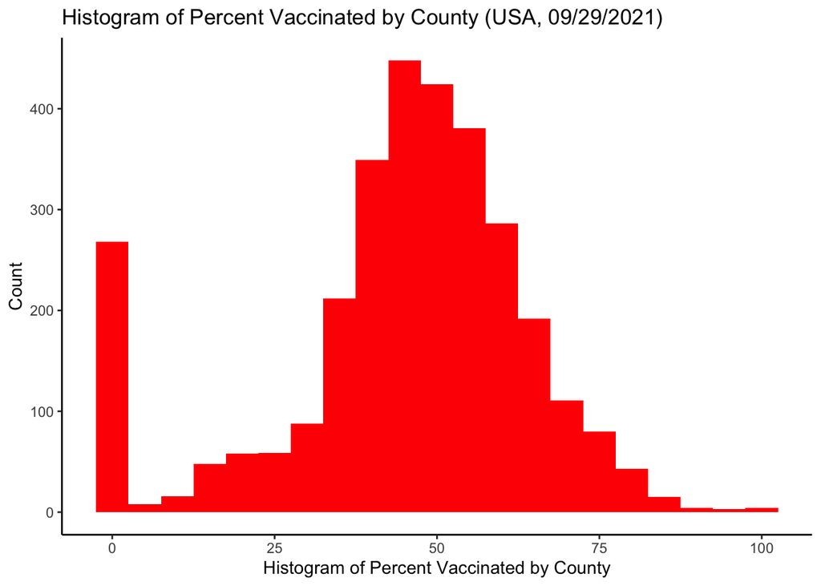

```r
#Now some plotting of distribution for each variable


#here we do % vaccinated
a <- complete %>% ggplot(aes(x=pct_vax)) + geom_histogram(fill="red", binwidth = 5.) + labs(title= "Histogram of Percent Vaccinated by County (USA, 09/29/2021)") + xlab("Histogram of Percent Vaccinated by County") +  ylab("Count") + theme_classic()
a
```

## Histogram of Main Predictor: Percent With Bachelors Degree

The figure below is a histogram of the main predictor variable, percent with a bachelors degree in each county. Here we see that the data is skewed with a tail to the right.

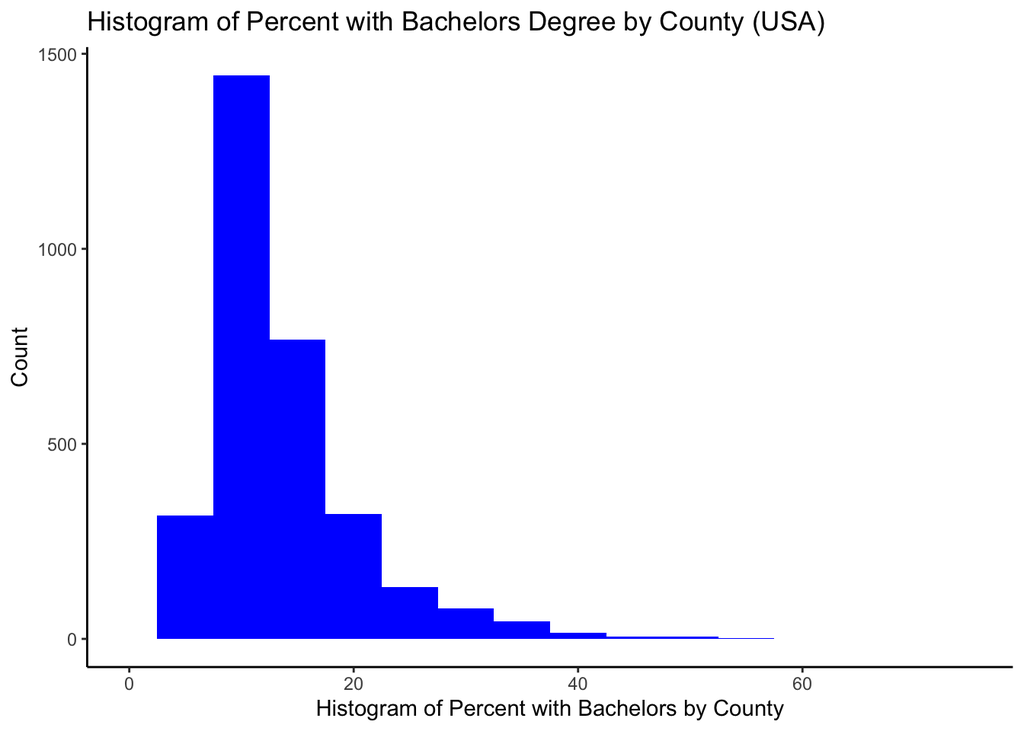

```r
#here we do % bachelors
b <- complete %>% ggplot(aes(x=pct_bachelors)) + geom_histogram(fill="blue", binwidth = 5) + xlim(0, 75) + labs(title= "Histogram of Percent with Bachelors Degree by County (USA)") + xlab("Histogram of Percent with Bachelors by County") +  ylab("Count") + theme_classic()
b
```

## Histograms of Other Continuous Covariates:

Here we can see that the other continuous variables do not appear to be normally distributed. Due to this, we will report medians and IQR's in our summary statistics table.

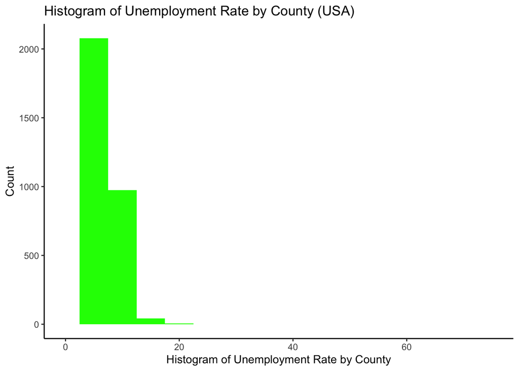

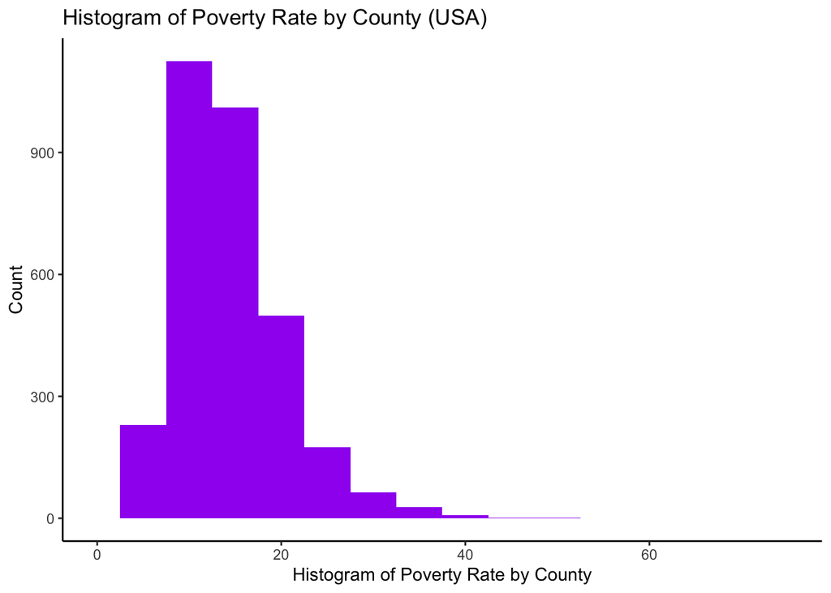

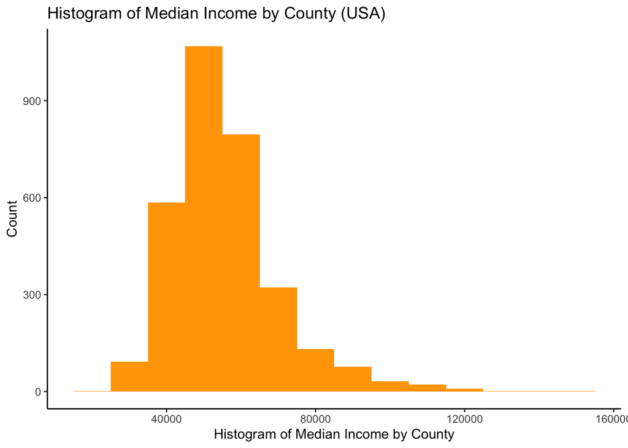

# More Data Management

The following code performs some data management in order to summarize each continuous variable.

```r
num_cols <- unlist(lapply(complete, is.numeric))         # identify numeric columns
complete_num <- complete[ , num_cols]                    #subset numeric columns of data



#here use a function to perform multiple calculations on the variables
#to get the median and IQR. notice that I use a transposition to get
#it in working order
table <- as.data.frame( t(sapply(complete_num, function(x) c(
                         "Median" = median(x, na.rm = T),
                         "25TH PCT" = unname(quantile(x, 0.25, na.rm = T)),
                         "75TH PCT" = unname(quantile(x, 0.75, na.rm = T)))


)))

#below I do a some more data management to add commas to large figures
table$Median <- prettyNum(table$Median, big.mark = ",", scientific = FALSE)
table$`25TH PCT` <- prettyNum(table$`25TH PCT`, big.mark = ",", scientific = FALSE)
table$`75TH PCT` <- prettyNum(table$`75TH PCT`, big.mark = ",", scientific = FALSE)

#i also combine the 25th percentile and 75th into a character string seperated by a "-"
table$IQR <- paste(table$`25TH PCT`, table$`75TH PCT`, sep = "-")

#then i add parentheses around it using this function
addparentheses <- function(x){paste("(", x, ")")}
table$IQR <- addparentheses(table$IQR)

# we don't need the first row or middle colums so we delete them
table <- table[ -c(1), -c(2,3)]

rownames(table) <-  c("Percent Vaccinated over 12 years", "Percent with Bachelors Degree or Higher", "Unemployment Rate (%)", "Median Household Income", "Poverty Rate (%)")
```

## Table of Summary Statistics:

The table below summarizes the median and interquartile range for each continous variable in the analysis.

```
##                                         Median               IQR
## Percent Vaccinated over 12 years          47.4         ( 38-57 )
## Percent with Bachelors Degree or Higher   11.8      ( 9.2-15.6 )
## Unemployment Rate (%)                      6.5         ( 5.2-8 )
## Median Household Income                 53,341 ( 46,243-62,059 )
## Poverty Rate (%)                          13.4     ( 10.4-17.5 )
```

Now I display the saved file for an improved aesthetic.

|  | Median | IQR |
| --- | --- | --- |
| Percent Vaccinated over 12 years | 47.4 | ( 38-57 ) |
| Percent with Bachelors Degree or Higher | 11.8 | ( 9.2-15.6 ) |
| Unemployment Rate (%) | 6.5 | ( 5.2-8 ) |
| Median Household Income | 53,341 | ( 46,243-62,059 ) |
| Poverty Rate (%) | 13.4 | ( 10.4-17.5 ) |

## Plotting The One Categorical Variable: Locality

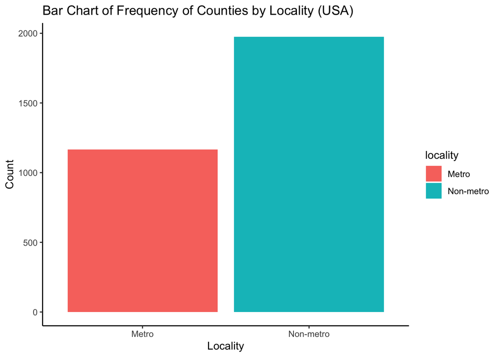